# Season-adjusted time-series DLNM (INLA)

Fintan Mooney

2026-08-26

```r
rm(list = ls())
project.folder = paste0(print(here::here()), '/')
```

```
## [1] "/Users/fmooney/Documents/hpai_outbreaks_mn"
```

```r
source(paste0(project.folder, 'create_folder_structure.R'))
```

```
## [1] "/Users/fmooney/Documents/hpai_outbreaks_mn"
```

```r
source(paste0(functions.folder, 'script_initiate.R'))
stopifnot(requireNamespace("INLA", quietly = TRUE))
library(INLA); library(Matrix)
INLA::inla.setOption(num.threads = 1)
source(paste0(functions.folder, 'inla_dlnm_helpers.R'))
```

Companion to the case-crossover in `c_11`, answering the question that design *cannot*.

A case-crossover matches each case to referents in the same cell within a few weeks, which throws away every between-season contrast by construction. It can only tell you whether a short-term deviation precedes an event. That matters here because 71% of Minnesota’s cases are in spring, so “why spring?” is a between-season question the matched design is blind to.

This model keeps the whole panel and adjusts for season **explicitly** instead: a cyclic RW2 over week-of-year absorbs the seasonal epidemic curve, an iid cell effect absorbs between-cell differences, and `feedlot_count` enters as the offset (only premises can have a spillover). Exposure effects are then identified from week-to-week deviations that survive the seasonal cycle — strictly more temporal signal than matching leaves behind.

## Meteorology only — and why

**No bird term goes in this model, and it must not.** `a_04_zone_bird_abundance_multistate` only extracts eBird abundance for *event* zones, because that is all the case-crossover ever needs. Across the full grid the result is that waterfowl abundance is non-zero in exactly the 77 cells that had an outbreak and zero in all 1,484 others — those zeros are missing data, not low counts. Any model that compares outbreak cells against non-outbreak cells therefore gets a bird variable that is a perfect indicator of case-cell status, and “discovers” a spillover association by construction. An earlier version of this file included the bird term and returned RR 1.45 (1.38, 1.51) with a 411-point WAIC gap; that was entirely circular.

ERA5 covers every cell, so the meteorological terms have no such problem and this model is valid for them. The waterfowl question stays in `c_11`, where cases and controls are days inside the *same* event cell and bird data exists for both. Extending the eBird raster extraction to all cells would make a bird term legitimate here; until then it is left out.

# 1. Weekly at-risk panel

```r
d   <- setDT(readRDS(paste0(objects_folder, multistate_ts_daily_rds)))
scr <- readRDS(paste0(objects_folder, multistate_independence_screening_rds))

# every case sits in a cell with at least one feedlot, so dropping the rest costs nothing
# and removes ~750 structurally-zero cells
mn <- d[state == "Minnesota" & feedlot_count > 0]

# same case definition as c_11: drop cross-farm CSLT/NOSEQ events
count_flagged <- function(s, ids) {
  if (is.na(s)) return(0L)
  as.integer(sum(as.numeric(trimws(unlist(strsplit(s, ",")))) %in% ids))
}
mn[, nf := vapply(outbreak_id, count_flagged, integer(1), ids = scr$cross_farm_ids)]
mn[, outbreak_count := pmax(outbreak_count - nf, 0L)][, nf := NULL]

MET  <- INLA_MET_VARS
VARS <- MET          # meteorology only — see the note above

# roll up to cell-weeks. fluxes accumulate over the week, states average.
sum_v  <- c("runoff", "precipitation")
mean_v <- setdiff(VARS, sum_v)
wk <- mn[, c(.(cases = sum(outbreak_count, na.rm = TRUE),
               feedlots = max(feedlot_count, na.rm = TRUE),
               wk_start = min(date)),
             lapply(.SD, mean, na.rm = TRUE)),
         by = .(zone_id, iso_year, iso_week), .SDcols = mean_v]
wk <- merge(wk, mn[, lapply(.SD, sum, na.rm = TRUE),
                   by = .(zone_id, iso_year, iso_week), .SDcols = sum_v],
            by = c("zone_id", "iso_year", "iso_week"))
setorder(wk, zone_id, wk_start)

# weekly lag matrix 0-4 wk, log1p the skewed ones, then z-scale so effects read per SD
for (v in VARS) {
  nm <- paste0(v, "_Lag", 0:4)
  wk[, (nm) := shift(.SD[[1]], n = 0:4, type = "lag"), by = zone_id, .SDcols = v]
}
for (v in intersect(c("runoff", "precipitation"), VARS)) for (k in 0:4) {
  cc <- paste0(v, "_Lag", k); wk[[cc]] <- log1p(pmax(wk[[cc]], 0))
}
for (v in VARS) for (k in 0:4) {
  cc <- paste0(v, "_Lag", k); wk[[cc]] <- as.numeric(scale(wk[[cc]]))
}
wk <- wk[complete.cases(wk[, paste0(rep(VARS, each = 5), "_Lag", 0:4), with = FALSE])]

cat(sprintf("%d cell-weeks | %d cells | %d weeks | %d cases\n",
            nrow(wk), uniqueN(wk$zone_id), uniqueN(wk$wk_start), sum(wk$cases)))
```

```
## 85855 cell-weeks | 1561 cells | 55 weeks | 86 cases
```

# 2. Fit

```r
cbs <- list(); cb_cols <- list()
dat <- data.frame(cases = wk$cases, E = wk$feedlots)
for (v in VARS) {
  X  <- as.matrix(wk[, paste0(v, "_Lag", 0:4), with = FALSE])
  cb <- dlnm::crossbasis(X, lag = c(0, 4), argvar = list(fun = "lin"),
                         arglag = list(fun = "ns", df = 2))
  colnames(cb) <- paste0("cb_", v, ".", colnames(cb))
  cbs[[v]] <- cb; cb_cols[[v]] <- colnames(cb)
  dat <- cbind(dat, as.data.frame(unclass(cb)))
}
dat$id_season <- wk$iso_week                              # cyclic seasonal curve
dat$id_space  <- as.integer(as.factor(wk$zone_id))        # cell-level differences
cbn <- unlist(cb_cols)

hyper.iid <- list(theta = list(prior = "pc.prec", param = c(1, 0.01)))
form <- paste0(
  "cases ~ 1 + offset(log(E)) + ",
  "f(id_season, model = 'rw2', hyper = hyper.iid, constr = TRUE, cyclic = TRUE) + ",
  "f(id_space,  model = 'iid', hyper = hyper.iid) + ",
  paste(cbn, collapse = " + "))

fit_ts <- INLA::inla(
  as.formula(form), data = dat, family = "poisson",
  control.fixed = list(correlation.matrix = TRUE,
    mean = as.list(setNames(rep(0, length(cbn)), cbn)),
    prec = as.list(setNames(rep(INLA_PREC_PRIMARY, length(cbn)), cbn)),
    prec.intercept = 0.001, mean.intercept = 0),
  control.compute = list(dic = TRUE, waic = TRUE, config = TRUE),
  control.inla = list(strategy = "simplified.laplace", int.strategy = "eb",
                      control.vb = list(enable = FALSE)),
  num.threads = 1)

saveRDS(fit_ts, paste0(models_folder, "timeseries_seasonal_mn.RDS"))
cat("WAIC", round(fit_ts$waic$waic, 1), "\n")
```

```
## WAIC 1203
```

# 3. Cumulative RR over the 0-4 wk lag window

```r
# same contrast machinery as c_11: build the lag contrast by hand off the stored covariance
ts_cumulative <- function(fit, cbs, cb_cols, vars, step = 0.5) {
  V <- fit$misc$lincomb.derived.covariance.matrix
  data.table::rbindlist(lapply(vars, function(v) {
    idx <- match(cb_cols[[v]], fit$names.fixed)
    b   <- fit$summary.fixed[idx, "mean"]
    W   <- colSums(do.call(dlnm::onebasis, c(list(x = 0:4), attr(cbs[[v]], "arglag"))))
    cv  <- step * W
    lo  <- sum(cv * b)
    se  <- sqrt(as.numeric(t(cv) %*% V[idx, idx] %*% cv))
    data.table::data.table(Predictor = unname(INLA_LABELS[v]),
      RR = exp(lo), low = exp(lo - 1.96 * se), high = exp(lo + 1.96 * se))
  }))[, `RR (95% CrI)` := sprintf("%.2f (%.2f, %.2f)", RR, low, high)][]
}
res_ts <- ts_cumulative(fit_ts, cbs, cb_cols, VARS)
print(res_ts[, .(Predictor, `RR (95% CrI)`)])
```

```
##         Predictor      RR (95% CrI)
##            <char>            <char>
## 1: Surface Runoff 0.98 (0.72, 1.33)
## 2:  Soil Moisture 0.92 (0.73, 1.15)
## 3:    Temperature 0.80 (0.45, 1.41)
## 4:  Precipitation 0.92 (0.64, 1.33)
## 5:     Wind Speed 0.91 (0.74, 1.11)
## 6:     Snow Cover 1.10 (0.84, 1.43)
```

```r
saveRDS(res_ts, paste0(objects_folder, "timeseries_seasonal_mn_results.RDS"))
```

# 4. Overdispersion check

```r
# 86 events in ~86k cell-weeks is sparse enough that Poisson should be fine, but the
# waterfowl interval is tight so it's worth confirming rather than assuming.
dat$id_obs <- seq_len(nrow(dat))
alt <- function(extra, fam) {
  f <- INLA::inla(as.formula(paste0(
      "cases ~ 1 + offset(log(E)) + ",
      "f(id_season, model='rw2', hyper=hyper.iid, constr=TRUE, cyclic=TRUE) + ",
      "f(id_space, model='iid', hyper=hyper.iid) + ", extra, paste(cbn, collapse=" + "))),
    data = dat, family = fam,
    control.fixed = list(correlation.matrix = TRUE,
      mean = as.list(setNames(rep(0, length(cbn)), cbn)),
      prec = as.list(setNames(rep(INLA_PREC_PRIMARY, length(cbn)), cbn)),
      prec.intercept = 0.001, mean.intercept = 0),
    control.compute = list(waic = TRUE, config = TRUE),
    control.inla = list(strategy = "simplified.laplace", int.strategy = "eb",
                        control.vb = list(enable = FALSE)), num.threads = 1)
  ts_cumulative(f, cbs, cb_cols, VARS)[, .(Predictor, `RR (95% CrI)`)]
}
cmp <- merge(res_ts[, .(Predictor, Poisson = `RR (95% CrI)`)],
             alt("f(id_obs, model='iid', hyper=hyper.iid) + ", "poisson")[
               , .(Predictor, `Poisson + OLRE` = `RR (95% CrI)`)], by = "Predictor", sort = FALSE)
cmp <- merge(cmp, alt("", "nbinomial")[, .(Predictor, NegBin = `RR (95% CrI)`)],
             by = "Predictor", sort = FALSE)
print(cmp)
```

```
##         Predictor           Poisson    Poisson + OLRE            NegBin
##            <char>            <char>            <char>            <char>
## 1: Surface Runoff 0.98 (0.72, 1.33) 0.98 (0.72, 1.33) 0.98 (0.72, 1.33)
## 2:  Soil Moisture 0.92 (0.73, 1.15) 0.92 (0.73, 1.15) 0.92 (0.73, 1.15)
## 3:    Temperature 0.80 (0.45, 1.41) 0.80 (0.45, 1.41) 0.80 (0.45, 1.41)
## 4:  Precipitation 0.92 (0.64, 1.33) 0.92 (0.64, 1.33) 0.92 (0.64, 1.33)
## 5:     Wind Speed 0.91 (0.74, 1.11) 0.91 (0.74, 1.11) 0.91 (0.74, 1.11)
## 6:     Snow Cover 1.10 (0.84, 1.43) 1.10 (0.84, 1.43) 1.10 (0.84, 1.43)
```

# 5. Seasonal and spatial terms

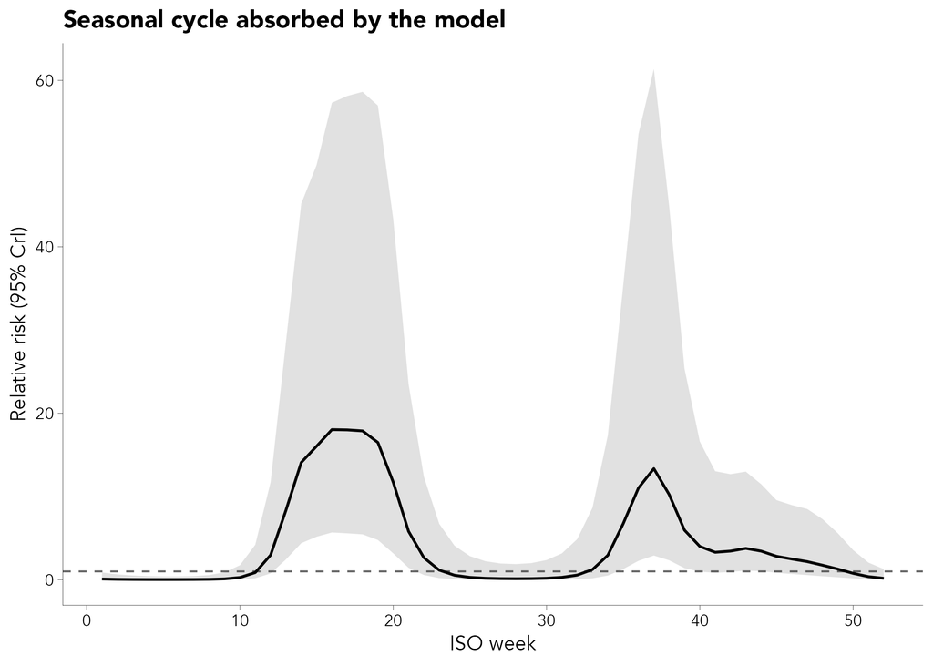

```r
s <- fit_ts$summary.random$id_season
p_season <- ggplot(data.frame(week = s$ID, RR = exp(s$`0.5quant`),
                              lo = exp(s$`0.025quant`), hi = exp(s$`0.975quant`)),
                   aes(week, RR)) +
  geom_hline(yintercept = 1, linetype = 2, colour = "gray40") +
  geom_ribbon(aes(ymin = lo, ymax = hi), alpha = 0.15) + geom_line(linewidth = 0.7) +
  labs(x = "ISO week", y = "Relative risk (95% CrI)",
       title = "Seasonal cycle absorbed by the model") +
  theme_spark() + theme(axis.text.x = element_text(angle = 0, hjust = 0.5))
ggsave_spark(file.path(figures_main_folder, "figure_ts_seasonal_curve.png"),
             p_season, width = 6.5, height = 4)
p_season
```